# Introduction to Python

## The Python Tutorial

https://docs.python.org/3/tutorial/

# Python basics

- naming variables, function, class, module or other object = identifiers
  - Starts with A_Z or a*z or*
  - Followed by n letters, underscores, digits, n>=0
  - No punctuation characters allowed, @, \$, \%
  - Case sensitive, mlp != MLP != mLp
- Naming convention
  - Class names start with an uppercase letter. All other identifiers start with a lowercase letter
  - Starting an identifier with a single leading underscore indicates that the identifier is private
  - Starting an identifier with two leading underscores indicates a strongly private identifier
  - If the identifier also ends with two trailing underscores, the identifier is a language-defined special name
- Lines and indentation
  - No braces to indicate blocks of code for class and function definitions or flow control
  - Blocks of code are denoted by line indentation
    - **Rigidly enforced**
    - Indend size variable - same within the block!
  - Multiline statements
    - Using \ or in any of Python parentheses

## Python Operators

- Arithmetic operators
- Comparison operators
- Logical operators
- Identity operators
- Membership operators
- Bitwise operators
- Assignment operator

### Arithmetic operators

```python
x = 10
y = 2.1

print('x + y =',x+y)
print('x - y =',x-y)
print('x * y =',x*y)
print('x / y =',x/y)
print('x % y =',x%y)    # modulus operator
print('x // y =',x//y)  # floor division
print('x ** y =',x**y)  # exponentiation operator

# change values of x and y variable and study the results
```

```
x + y = 12.1
x - y = 7.9
x * y = 21.0
x / y = 4.761904761904762
x % y = 1.5999999999999996
x // y = 4.0
x ** y = 125.89254117941675
```

### Comparison Operators

```python
x = 10
y = 12

print('x > y is',x>y)
print('x < y is',x<y)
print('x == y is',x==y)
print('x != y is',x!=y)
print('x >= y is',x>=y)
print('x <= y is',x<=y)
```

```
x > y is False
x < y is True
x == y is False
x != y is True
x >= y is False
x <= y is True
```

### Logical operators

```python
x = True
y = False

print('x and y is',x and y)

print('x or y is',x or y)

print('not x is',not x)
```

```
x and y is False
x or y is True
not x is False
```

### Identity operators

- is/is not
- Used to check if two values (or variables) are located on the same part of the memory
- Two variables that are equal does not imply that they are identical

```python
x1 = 5
y1 = 5
x2 = 'Hello'
y2 = 'Hello'
x3 = [1,2,3]
y3 = [1,2,3]

print(x1 is not y1)
# x1 and y1 are integers of the same values, so they are equal as well as identical

print(x2 is y2)
# x2 and y2 are the same strings, thus equal and identical.

# Output: False
print(x3 is y3)
# x3 and y3 are lists. Equal but not identical.
# It is because the interpreter locates them separately in memory although they are equal.
```

```
False
True
False
```

### Membership operators

```python
x = 'Hello world'
y = {1:'a',2:'b'}

print('x' in x)
print('hello' not in x)
print(1 in y)
print('a' in y)
```

```
False
True
True
False
```

### Bitwise operators

- Act on operands as if they were strings of binary digits
- Operate bit by bit

```python
def decimalToBinary(n):
    return bin(n).replace("0b", "")

x = 10
print("{0:#b}".format(x))
print (bin(x))
print(decimalToBinary(x))

y = 2
print("{0:#b}".format(y))
print (bin(y))
print(decimalToBinary(y))

# bitwise AND
print('x & y is',x&y)
# bitwise OR
print('x | y is',x|y)
# bitwise NOT
print('~x is',~x)
# bitwise XOR
print('x ^ y is',x^y)
#logical shifts - useful to perform multiplication or division of unsigned integers by powers of two
# bitwise right shift
print('x >> y is',x>>y)
# bitwise left shift
print('x << y is',x<<y)
```

```
0b1010
0b1010
1010
0b10
0b10
10
x & y is 2
x | y is 10
~x is -11
x ^ y is 8
x >> y is 2
x << y is 40
```

### Assignments Operators

```python
x = 5
x += 5 # same as x = x + 5
print(x)

x = 5
x -= 5
print(x)

x = 5
x *= 5
print(x)

x = 5
x /= 5
print(x)

x = 5
x %= 5
print(x)

x = 5
x //= 5
print(x)

x = 5
x **= 5
print(x)
```

```
10
0
25
1.0
0
1
3125
```

```python
# bitwise assignments
print('5 is ', decimalToBinary(5), ' in binary')

x = 5
x &= 5
print(x)

x = 5
x |= 5
print(x)

x = 5
x ^= 5
print(x)

x = 5
x >>= 2
print(x)

x = 5
x <<= 1
print(x)
```

```
5 is  101  in binary
5
5
0
1
10
```

## Assigning Values to Variables

- No need for explicit declaration to reserve memory space
- Automatic declaration when a value assigned to a variable with sign (=)

```python
name = 'Peter'
distance = 25
pi = 3.14

print(name, '\n', distance, '\n', pi)
```

```
Peter
 25
 3.14
```

### Multiple Assignment

- Assign a single value to several variables simultaneously
- Be aware of aliasign on data types such as dictionaries and lists

Create an integer object with the value 10 and assign it to the same memory location

```python
x = y = z = 10
print (x, y, z)
print(x is y)
```

```
10 10 10
True
```

```python
x, y, z = 10, 12, 'Jack'
print (x, y, z)
```

```
10 12 Jack
```

## Functions

- Block of organized, reusable code that is used to perform a single, related action
- Provide better modularity for your application
- Better code reusability

### User-Defined vs Build-in Functions

- The Python interpreter has a number of functions that are always available
- for example:
  - print()
  - list()
  - len()
  - range()
  - input()
- Full list of build-in functions: https://docs.python.org/3/library/functions.html

#### Defining a Function

- Begin with the keyword def followed by the function name and parentheses
- Input parameters or arguments should be placed within these parentheses
- You can also define parameters inside these parentheses
- The first statement of a function can be an optional statement
  - the documentation string of the function or docstring
- **The code block within every function starts with a colon (:) and is indented**
- The statement return [expression] exits a function
- Return statement with no arguments is the same as return None

```python
# example of syntax how to define function
def sumtwonumbers(a,b):
    return a+b
# calling the function
sumtwonumbers(5,13)
```

```
18
```

```python
# Default Arguments
def sumtwonumbers(a,b=10):
    return a+b
```

```python
# we can call function with defauls argument by giving all argument in
sumtwonumbers(5,15)
```

```
20
```

```python
# or we can use the default argument to be used and enter only non-default arguments
c = sumtwonumbers(5)
print(c)
```

```
15
```

```python
#Python allows to use variable-length arguments with * operator
def sumnnumbers(a,*b):
    # forst we set the variable c to be 0, because later we will assing a nex value in each step of for loop
    c = 0
    for number in b:
        c = c + number # this sums all number in b input
    c = a + c # add a to the sum of b
    return c
```

```python
# caling the function with all mandatory input (i.e. 1 input)
sumnnumbers(10)
```

```
10
```

```python
# calling the function with arbitrary length of input
sumnnumbers(5, 4, 1, 3)
```

```
13
```

## Conditionals

- Using test conditions to change the program behaviour depending on the outcome of the tests
- Based on Boolean values and expressions

```python
5 > (3 + 3)
```

```
False
```

### Conditional execution

```python
x=10
if x % 2 == 0:
    print(x, " is even.")
    print("Did you know that 2 is the only even number that is prime?")
else:
    print(x, " is odd.")
    print("Did you know that multiplying two odd numbers " +   "always gives an odd result?")
```

```
10  is even.
Did you know that 2 is the only even number that is prime?
```

### Chained conditionals

```python
choice = 'x'
if choice == "a":
    function_one()
elif choice == "b":
    function_two()
elif choice == "c":
    function_three()
else:
    print("Invalid choice.")
```

```
Invalid choice.
```

# Data Types in Python

- Many types of data that can be stored in memory
- For instance:
  - a person's age is stored as a numeric value
  - a person's address is stored as alphanumeric characters
- Python has various standard data types
  - operations possible
  - storage method

- Number
  - int (signed integers) - all long int
  - float (floating point real values)
  - complex (complex numbers)
- String
- List
- Tuple
- Dictionary
- Sets

### Sequence

- Sequences allow you to store multiple values in an organized and efficient fashion
- Several sequence types: strings, lists, tuples
- Dictionaries and sets are containers for non-sequential data

### Numbers

```python
# this data type stores numeric values
x = 10
y = 100.23
z = 1+2j
# you can delete a single or multiple objectcs
del x, y, z
```

### Strings

- Continuous set of characters within quotation marks
  - using '' or ""
- String subsets using slice operators [], [:]
- Indexing starts at 0, and ends at -1

```python
# define string s
s = 'Hello Python!'
# each print statement prints out the result of operation made on string s

print (s)          # Prints complete string
print (s[0])       # Prints first character of the string
print (s[2:5])     # Prints characters starting from 3rd to 5th
print (s[2:])      # Prints string starting from 3rd character
print (s[-1])      # Prints last char of the string
print (s * 2)      # Prints string two times
print (s + "TEST") # Prints concatenated string
```

```
Hello Python!
H
llo
llo Python!
!
Hello Python!Hello Python!
Hello Python!TEST
```

### Lists

- The most versatile of Python's data types
- Contains items separated by commas and enclosed within square brackets
- Items belonging to a list can be of different data type
- Item can be addressed using slice operator ":". Slices refers to subset of original list

```python
# define list l1 and list l2
l1 = [ 'mlp', 786 , 2.23, 'Jack', 70.2 ]
l2 = [123, 'Jack']

print (l1)          # Prints complete list
print (l1[0])       # Prints first element of the list
print (l1[1:3])     # Prints elements starting from 2nd till 3rd
print (l1[2:])      # Prints elements starting from 3rd element
print (l2 * 2)      # Prints list two times
print (l1 + l2)     # Prints concatenated lists
l1[0] = 'course'
del l1[1]
print(l1)
```

```
['mlp', 786, 2.23, 'Jack', 70.2]
mlp
[786, 2.23]
[2.23, 'Jack', 70.2]
[123, 'Jack', 123, 'Jack']
['mlp', 786, 2.23, 'Jack', 70.2, 123, 'Jack']
['course', 2.23, 'Jack', 70.2]
```

```python
# another way of creating subset of list
# Here we omit start/stop parameters and use only step.
print(l1)
l3 = l1[::-1] # reverse indexing
print(l3)

# by providing start we can skip some elements:
l4 = l1[1::2] # chose 2nd and 4th index
print(l4)
```

```
['course', 2.23, 'Jack', 70.2]
[70.2, 'Jack', 2.23, 'course']
[2.23, 70.2]
```

#### Python Example

Having a list variable. How to select arbitrary indices from a list?

```python
original_list = [14,23,32,44,57,68,79] # can be list with age of users
list_of_indices = [1,3,5] # indices with users who smokes

# first, we define the empty list
list_of_smokers_age = []
for ind in list_of_indices:
    print(original_list[ind]) # this prints out the age of smokers
    list_of_smokers_age.append(original_list[ind]) # here we use build-in method append(), which is made on data type list and adds a value to a given list
print("age of all users:", original_list)
print("age of all smokers:", list_of_smokers_age)
```

```
23
44
68
age of all users: [14, 23, 32, 44, 57, 68, 79]
age of all smokers: [23, 44, 68]
```

```python
# one liner with list comprehensions (this concept of list comprehensions will be explained later)
# this example shows the magic of Python ;)
list_of_smokers_age = [original_list[ind] for ind in list_of_indices]
print(list_of_smokers_age)
```

```
[23, 44, 68]
```

### Tuples

- Sequence data type used to store multiple items in a single variable
- A tuple is a collection which is ordered and unchangeable/ immutable - e.g. once created you cannot add/remove/swap elements
- Read only lists

```python
mytuple = ( 'hi', 12 , 1.23, 'Martin', 70.2  )
tinytuple = (123, 'Meggie')

print (mytuple)           # Prints complete tuple
print (mytuple[0])        # Prints first element of the tuple
print (mytuple[1:3])      # Prints elements starting from 2nd till 3rd
print (mytuple[2:])       # Prints elements starting from 3rd element
print (tinytuple * 2)   # Prints tuple two times
print (mytuple + tinytuple) # Prints concatenated tuple
```

```
('hi', 12, 1.23, 'Martin', 70.2)
hi
(12, 1.23)
(1.23, 'Martin', 70.2)
(123, 'Meggie', 123, 'Meggie')
('hi', 12, 1.23, 'Martin', 70.2, 123, 'Meggie')
```

```python
# define tupple
julia = ("Julia", "Roberts", 1967, "Duplicity", 2009, "Actress", "Atlanta, Georgia")
print(julia)
```

```
('Julia', 'Roberts', 1967, 'Duplicity', 2009, 'Actress', 'Atlanta, Georgia')
```

```python
# this shows the immutability fo tuple, i.e. one defined - it cannot be changed
# uncomment the command below to check it - it is commented not the get error when compiling html page from this notebook

# julia[0] = "X"
```

```python
# How to create new tuple with reference to the old one
julia = julia[:3] + ("Eat Pray Love", 2010) + julia[5:]
print(julia)
```

```
('Julia', 'Roberts', 1967, 'Eat Pray Love', 2010, 'Actress', 'Atlanta, Georgia')
```

#### Tuple assignment

- mytuple = yourtuple
- The left side is a tuple of variables
- The right side is a tuple of values
- Each value is assigned to its respective variable
- All the expressions on the right side are evaluated before any of the assignments -> quite versatile (more in excercise section)

```python
# tuple assignments - useful when you want to assign more than one variable at a time when the left side is a sequence
# good for example for database operations
(name, surname, b_year, movie, m_year, profession, b_place) = julia
print(surname)
```

```
Roberts
```

#### Tuple as return values

- Functions in basic form always only return a single value
- Making that value a tuple, we can effectively group together as many values as we like, and return them together

```python
# Example: "Function that returns (circumference (c), area (a)) of a circle of radius r "
import math # in this module, there is function pi, which we will use
def get_values(r):
    c = 2 * math.pi * r
    a = math.pi * r * r
    return (c, a)

print(get_values(1))
print(type(get_values(1)))
```

```
(6.283185307179586, 3.141592653589793)
<class 'tuple'>
```

```python
# We can access each possition in tuble by iterable unpacking of tuple
# For example, we can unpack the tuple returned by function get_values and assing it to variable c and a

# get unpacked c and a values
c,a = get_values(1)
print(c)
print(a)
print(type(c), type(a) )

# get tuple
ca = get_values(1)
print(ca)
print(type(ca))
```

```
6.283185307179586
3.141592653589793
<class 'float'> <class 'float'>
(6.283185307179586, 3.141592653589793)
<class 'tuple'>
```

### Dictionaries

- Python's dictionaries are sort of hash-table type or mapping type
- Consist of key-value pairs
- A key can be almost any Python type, but are usually numbers or strings
- Values, on the other hand, can be any arbitrary Python object
- Indexing by using keys
- No duplicate keys
- Many datasets have dictionary format - easy to use

```python
# defien dictionary
d1 = {} # empty dictionary
d1['one'] = "This is 1" # define string value "This is 1" in dictionary position addressed by key "one"
d1[2]     = "This is 2"

print(d1)
print (d1['one'])       # Prints value for 'one' key
print (d1[2])           # Prints value for 2 key
```

```
{'one': 'This is 1', 2: 'This is 2'}
This is 1
This is 2
```

```python
# create dictionary d2 with 3 key-value pairs
d2 = {'name': 'Jack','code':6734, 'dept': 'sales'}
print (d2)              # Prints complete dictionary
print (d2.keys())       # Prints all the keys
print (d2.values())     # Prints all the values
```

```
{'name': 'Jack', 'code': 6734, 'dept': 'sales'}
dict_keys(['name', 'code', 'dept'])
dict_values(['Jack', 6734, 'sales'])
```

### Sets

- Used to store multiple items in a single variable
- Unordered - can appear in a different order every time you use them, and cannot be referred to by index or key.
- Unindexed, unchangeable
- Duplicates not allowed - ignored
  - Because sets cannot have multiple occurrences of the same element, it makes sets highly useful to efficiently remove duplicate values from a list or tuple and to perform common math operations like unions and intersections.

```python
set1 = {"abc", 34, True, 40, "male"}
print(set1)
```

```
{True, 34, 'abc', 'male', 40}
```

```python
set2 = set() # define empty set
print(set2)
set3 = set((1, False, "cherry")) # note the double round-brackets
print(set3)
set4 = set((0, False, "cherry")) # duplicates ignored
print(set4)
```

```
set()
{False, 1, 'cherry'}
{0, 'cherry'}
```

## Aliasing

- Alliasing happens whenever one variable is assigned to another variable
- Depends on data type

### Aliasing for Data Type String

- Not an issue because Strings are immutable - cannot be changed
- Whenever we change a string, Python actually creates a new string behind the scenes.

```python
# lets define two variables, each refer to a string object "banana"
a = "banana"
b = "banana"
# do a and b have the same value = are they equal?
print(a == b) # identical!!!

# do a and b refer to the same object = are they identical?
print(a is b) # identical!!!
```

```
True
True
```

- Since strings are immutable, Python optimizes resources by making two names that refer to the same string value refer to the same object

[figure not shown]

- No Aliasing problem

```python
# example to show the immutability of string and no aliassing for string
a = 'banana'
b = a
a = "apple"
print(a, b)
a is b
```

```
apple banana
```

```
False
```

### Aliasing for Data Type List and Dictionary

- Lists and dictionaries - mutable - i.e. can be altered if identical

[figure not shown]

- If we assign one variable to another, both variables refer to the same object

[figure not shown]

```python
# defining two separate lists
a = [1, 2, 3]
b = [1, 2, 3]
print(a == b) # are equal
print(a is b) # are not identical!!!
```

```
True
False
```

```python
# assinging one list to another - i.e. making aliased variable
a = [1, 2, 3]
b = a
print(a == b) # are equal
print(a is b) # are identical!!!
```

```
True
True
```

```python
# Changing one implies changes in another!!! - aliased
b[0] = 5
a
```

```
[5, 2, 3]
```

### Avoiding Aliasing

- Cloning list

```python
a = [1, 2, 3]
b = a[:] # cloning
print(b)
b[0] = 5
print(a)
```

```
[1, 2, 3]
[1, 2, 3]
```

- Copying of dictionaries

```python
opposites = {"up": "down", "right": "wrong", "yes": "no"}
alias = opposites # alias and opposites refer to the same object
copy = opposites.copy()  # copy refers to a fresh copy of the same dictionary = shallow copy
```

```python
# if we modify alias, opposites is also changed
alias["right"] = "left"
opposites["right"]
```

```
'left'
```

```python
# if we modify copy, opposites is unchanged
copy["right"] = "privilege"
opposites["right"]
```

```
'left'
```

## Type Conversion

- We can convert data types mutually by either implicit or explicit conversion

### Implicit Type Conversion

- The Python interpreter automatically converts one data type to another without any user involvement

### Explicit Type Conversion

- In Python, the data type can be manually changed. Various form of explicit type conversion are explained below.

```python
# implicit conversion
x = 10
print("x is of type:",type(x))

y = 10.6
print("y is of type:",type(y))

x = x + y
print(x)
print("x is of type:",type(x))
```

```
x is of type: <class 'int'>
y is of type: <class 'float'>
20.6
x is of type: <class 'float'>
```

```python
# explicit conversion

# using int(), float()
s = "10010"
# printing string converting to int base 2
c = int(s, 2)
print ("After converting to integer base 2 : ", c)
# printing string converting to float
e = float(s)
print ("After converting to float : ", e)

# using ord()
s = 'M'
# printing character converting to integer
c = ord(s)
print ("After converting character 'M' to integer : ", c)

# using  tuple(), set(), list()
s = 'geeks'
# printing string converting to tuple
c = tuple(s)
print ("After converting string to tuple : ",c)
# printing string converting to set
c = set(s)
print ("After converting string to set : ",c)
# printing string converting to list
c = list(s)
print ("After converting string to list : ",c)
```

```
After converting to integer base 2 :  18
After converting to float :  10010.0
After converting character 'M' to integer :  77
After converting string to tuple :  ('g', 'e', 'e', 'k', 's')
After converting string to set :  {'k', 's', 'e', 'g'}
After converting string to list :  ['g', 'e', 'e', 'k', 's']
```

```python
# using  dict(), complex(), str()

# initializing integers
a = 10
b = 2

# initializing tuple
tup = (('a', 1) ,('f', 2), ('g', 3))

# printing integer converting to complex number
c = complex(1,2)
print ("After converting integer to complex number : ",end="")
print (c)

# printing integer converting to string
c = str(a)
print ("After converting integer to string : ",end="")
print (c)

# printing tuple converting to expression dictionary
c = dict(tup)
print ("After converting tuple to dictionary : ",end="")
print (c)
```

```
After converting integer to complex number : (1+2j)
After converting integer to string : 10
After converting tuple to dictionary : {'a': 1, 'f': 2, 'g': 3}
```

```python
# Convert ASCII value to characters
a = chr(64)
b = chr(77)

print(a)
print(b)
```

```
@
M
```

## Indexing

- more information on how Python use indexing, slicing, negative indexing, etc. https://railsware.com/blog/python-for-machine-learning-indexing-and-slicing-for-lists-tuples-strings-and-other-sequential-types/

### Data Types Methods and Build-in Functions

- For each data type Python has a set of built-in functions or so called build-in methods that you can use
- Example of methods you can use on lists
  - append()
  - copy()
- Full list of build-in methods for each data type
- https://www.w3schools.com/python/python_reference.asp

# Python parentheses primer

- This section explains how to use various parentheses in Python
- Regular parentheses - ()
  - Callables (functions and classes)
  - Prioritizing operations
  - Creating tuples
  - Generator expressions
  - Cheating Python’s indentation rules
- square brackets - []
  - Creating lists
  - Requesting individual items
  - Requesting slices
- Curly braces — {}
  - Creating dicts
  - Create sets
  - Str.format
  - F-strings

### Regular parentheses

##### Calling functions and creating new objects

```python
# calling functions and creating new objects
x = len('abcd')
print(x)
i = int('12345')
print(i)
```

```
4
12345
```

##### Prioritizing operations

```python
# prioritizing operations
# division and multiplication before addition and subtraction
print(2 + 3 * 4)

# change the priority by using round parentheses
print((2 + 3) * 4)
```

```
14
20
```

##### Creating tuples

```python
# creating tuples
t = (10,20,30)
type(t)

# you do not need () to create tuple, it is good to use them for more readability of your code
T = 10,20,30
type(t)

# implication of using () to create tuple is that by returning multiple values from a function you’re actually returning a tuple
def foo():
    return 10, 20, 30
x = foo()
print(x)
```

```
(10, 20, 30)
```

```python
# define tuple of length 1
t = (10)
print(type(t))  # it is integer, why? compare to t = (8+2), this we dont want to be a tuple but an integer

t = (8+2)
print(type(t))

# when defining tuple of length 1, use comma
t = (10,)
type(t)
```

```
<class 'int'>
<class 'int'>
```

```
tuple
```

##### Regular parentheses usage for generator expressions

- generators
  - an advance topic (comprehensions and iterators)
  - very useful
  - allows to describe a sequence of data without creating each element of that sequence
- generator is iterable
  - can be placed inside for loop
  - can represent potentially infinite sequence of data without actuall need to install an infinite amount of RAM on our computers
  - we can retrieve items from our iterable one at a time

```python
# example of creating generator object
# generator expressions are surrounded by parenthesis ()
g = (n * n for n in range(10)) # creates generator

l = [n * n for n in range(10)] # creates list using given generator g

# compare the following
print(g)
print(list(g))
print(l)
```

```
<generator object <genexpr> at 0x7c5d2d5492a0>
[0, 1, 4, 9, 16, 25, 36, 49, 64, 81]
[0, 1, 4, 9, 16, 25, 36, 49, 64, 81]
```

```python
# example of using generator to iterate through a range of values

r = range(10) # range is a build-in function that creates a sequence of numbers in given range "range(start, stop, step)", default start and step is 0 and 1, resp.
print(type(r))
print(list(r)) # if you want to see what values are in the variable r

g = (n * n for n in range(10)) # creates iterator
for item in g: # iterrable - for each item generated by our generator we do defined steps (in this case it is only print)
    print(item)
```

```
<class 'range'>
[0, 1, 2, 3, 4, 5, 6, 7, 8, 9]
0
1
4
9
16
25
36
49
64
81
```

```python
# Example using generator:
# Having a given list of integers, how to convert it to a string that contains given elements or separators

mylist = [10, 20, 30, 344] # define list
ch = ',' # string defined as a comma character that we want to add to our resulting string and that separates the original list values

# we use join() build-in methods, basic syntax = string.join(iterable)
s2 = ch.join(str(x) for x in mylist) # error due to type list, note that "str(x) for x in mylist" is our generator which is an iterable
print(s2)

# with
# ','.join(mylist)
# there will be an error due to type list in join() argument

# example oj join() function
' and '.join(['1','2'])

s3 = '--'.join(str(x) for x in mylist) # error due to type list, note that "str(x) for x in mylist" is our generator which is an iterable
print(s3)
```

```
10,20,30,344
10--20--30--344
```

##### Regular parentheses usage for cheating Python’s indentation rules

```python
# lets say that we wan to find letter "e" in a given dictionary containing personal data
person = {'first':'Reuven', 'last':'Lerner', 'email':'reuven@lerner.co.il'} # define dictionary
```

```python
 # first method - hard to read what is going on
 if 'e' in person['first'] or 'e' in person['last'] or 'e' in person['email']:
    print("Found it!")
```

```
Found it!
```

```python
# second way - better for readibility - using \ to allow multiline code
if 'e' in person['first'] or \
    'e' in person['last'] or \
    'e' in person['email']:
    print("Found it!")
```

```
Found it!
```

```python
 # third way - using () allows you to use multiline code - reads well!
 if (
    'e' in person['first'] or
    'e' in person['last'] or
    'e' in person['email']
     ):
     print("Found it!")
```

```
Found it!
```

### Square brackets

##### Creating lists

```python
# creating lists
mylist = [ ]  # empty list
print(mylist)

mylist = [3, 2, 1]  # list with three items
print(mylist)
```

```
[]
[3, 2, 1]
```

##### List comprehensions

- simialar to generators
- output is a list
- general syntax
  - [ \ for \ in \ if \]

```python
# create lists via list comprehensions
l1 = [n * n for n in range(10) if n > 5]
print(l1)
```

```
[36, 49, 64, 81]
```

##### Requesting individual items

- use square brackets to retrieve from a sequence or dictionary

```python
l = [2, 3,5]
t = (10, 20, 30)
d = {'a':1, 'b':2, 'c':3}

print(l[0])
print(t[1])
print(d['c'])
```

```
2
20
3
```

##### Requesting slices

- slices are similar to individual indexes
- slices describe a range of indexes
- [start:end+1] or [start:end+1:stepsize]

```python
s = 'klmnopq'
s[3:5]
```

```
'no'
```

```python
s[:-2]
```

```
'klmno'
```

```python
s[0:-1:2]
```

```
'kmo'
```

```python
s = slice(0,26,2) # slice(start,stop, end)
import string
print(string.ascii_lowercase) # get entire small letter alphabet using string collection of constants (thus import string)
print(string.ascii_lowercase[s]) # get slices defined as s from the collection (small alphabet)
```

```
abcdefghijklmnopqrstuvwxyz
acegikmoqsuwy
```

### Curly braces

##### Creating dictionaries

```python
d = {}
len(d)
```

```
0
```

```python
# dict with key-value pairs
d = {'a':1, 'b':2, 'c':3}
len(d)
```

```
3
```

```python
# create dictionary using conversion from list
dict(['ab', 'cd', 'ef'])
```

```
{'a': 'b', 'c': 'd', 'e': 'f'}
```

```python
# create dictionary from list of tuples
dict([('a', 1), ('b', 2), ('c', 3)])
```

```
{'a': 1, 'b': 2, 'c': 3}
```

```python
# using generator to create dictionary
{ n : n*n for n in range(10) } # notice the difference when defining output in generator - here "n:n*n" - which is the format of a dictionary data type
```

```
{0: 0, 1: 1, 2: 4, 3: 9, 4: 16, 5: 25, 6: 36, 7: 49, 8: 64, 9: 81}
```

##### Creating sets

- dictionaries without any values

```python
s = {10,20,30}
type(s)
```

```
set
```

```python
s = set()
s.add(10) # use add() build-in function to add a value to defined set s
s
```

```
{10}
```

```python
# remove duplicate entries from a list using sets and unpacking operator *
mylist = [10, 20, 30, 10, 20, 30, 40]
{*mylist} # create list without repetition, * operator tells to use mylist without []
```

```
{10, 20, 30, 40}
```

```python
print(mylist)
print(*mylist)
```

```
[10, 20, 30, 10, 20, 30, 40]
10 20 30 10 20 30 40
```

##### Curly braces for usage in concept of "str.format"

- string formating
- you can use printf-style with % or the modern f-string
- output of f-string is not a print, you can assign it to a new variable, save it, print it

```python
# example
name = 'Martin' # define string variable
print("Hello, {0}".format(name)) # use str.format() method
```

```
Hello, Martin
```

```python
# anpther way of using str.format()
# manual vs auto numbering in curly braces
a, b, c = [1, 2, 3]
print('a = {}, b = {}, c = {}'.format(a, b, c)) # here braces {} are empty, so variables are auto assgned to positions
```

```
a = 1, b = 2, c = 3
```

```python
a, b, c = [1, 2, 3]
print('a = {0}, b != {0}, c = {2}'.format(a, b, c)) # here braces {} contain index of variable to be assigned
```

```
a = 1, b != 1, c = 3
```

```python
print('a = {x}, b = {y}, c = {z}'.format(x=a, y=b, z=c))
```

```
a = 1, b = 2, c = 3
```

##### Curly braces for f-strings

- adding “f” before the opening quotes allows us to use curly braces to interpolate just about any Python expression we want inside of a string — from variable names to operations to function/method calls
- check string methods https://www.w3schools.com/python/python_ref_string.asp

```python
print(f"Hello, {name}")
```

```
Hello, Martin
```

```python
print(f"Hello, {name.upper()}")
```

```
Hello, MARTIN
```

```python
print(f"Hello, {name.split('a')}")
```

```
Hello, ['M', 'rtin']
```

# PYTHON MODULES

- module is a code library containing a set of functions
- using module
  - load it with import command

### Matplotlib, Seaborn, Pandas, scikit-learn, Numpy

#### Matplotlib

- low level graph plotting library
- most utilities under pyplot ~ plt alias
- many tunable parameters - https://matplotlib.org/

#### Numpy

- module alloving to work with multidimensional arays
- https://numpy.org/doc/stable/user/quickstart.html#the-basics
- np arrays are faster and more compact than Python lists, consumes less memory, lots of useful build-in mechanisms np.arrange, np.linspace, np.sort, np. ones, np.zeros, np.argsort, ...

#### Scipy

- module supporting mathematics, science, and engineering
- good for statistics, signal processing
- https://www.scipy.org/

#### Pandas

- data analysis and manipulation tool
- https://pandas.pydata.org/docs/user_guide/index.html

#### Seaborn

- complimentary package to Matplotlib
- very useful for statistical graphics and powerful with pandas objects
- https://seaborn.pydata.org/

#### scikit-learn

- simple and efficient tool for predictive analysis aka ML
- https://scikit-learn.org/stable/index.html

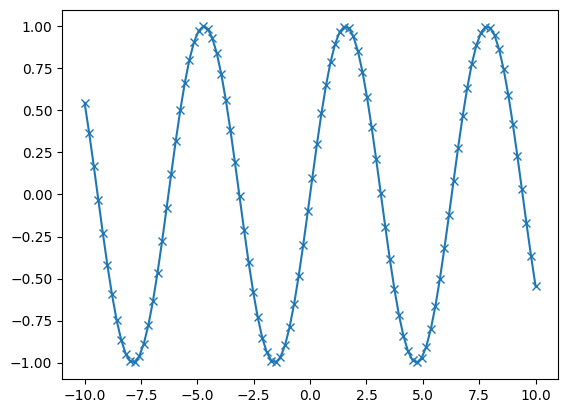

```python
# How to plot a simple graph
# import modules using "as" to be able to refer to them via defined shortcut
import matplotlib.pyplot as plt
import numpy as np
# Generate a sequence of numbers from -10 to 10 with 100 steps in between
x = np.linspace(-10, 10, 100)
# Create a second array using sine
y = np.sin(x)
# The plot function makes a line chart of one array against another
plt.plot(x, y, marker="x")
```

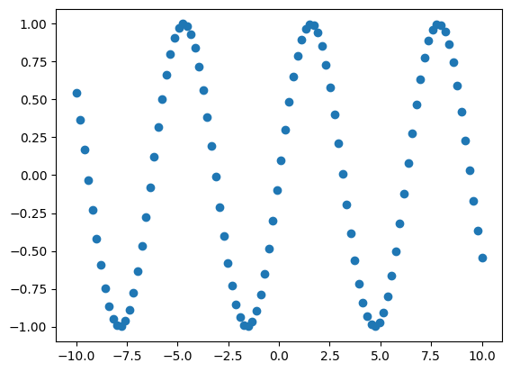

```python
plt.plot(x, y, 'o')
```

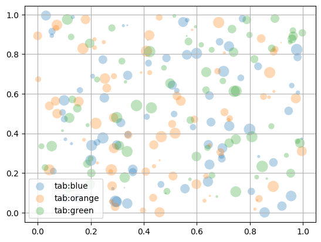

```python
fig, ax = plt.subplots() # initiate figure and axis to use them for plots
for color in ['tab:blue', 'tab:orange', 'tab:green']:
    n = 75
    x, y = np.random.rand(2, n)
    scale = 200.0 * np.random.rand(n)
    # scatter() is a method that can be used in axis object to plot a scatter plot
    ax.scatter(x, y, c=color, s=scale, label=color,
               alpha=0.3, edgecolors='none')

ax.legend()
ax.grid(True)
```

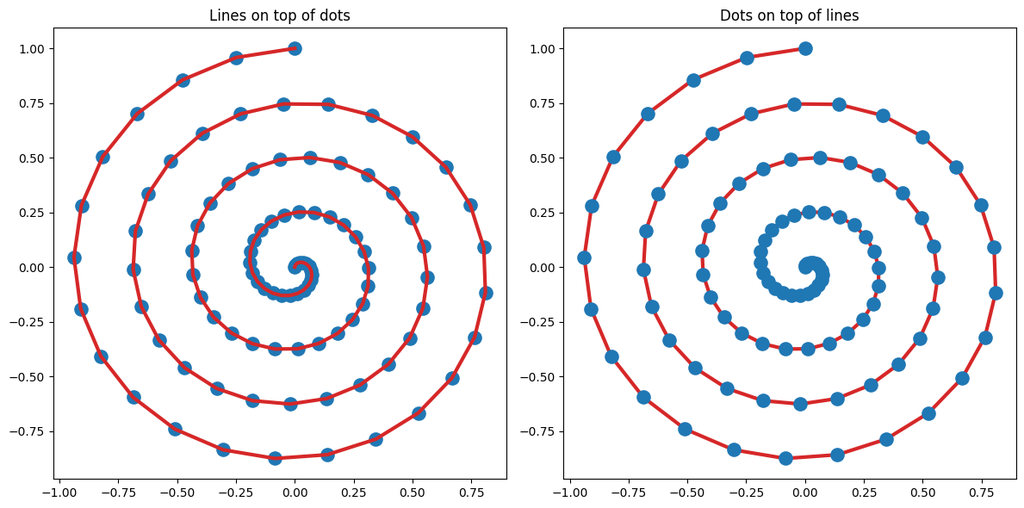

```python
r = np.linspace(0, 1, 100)
theta = np.linspace(0, 8*np.pi, 100)
x = r * np.sin(theta)
y = r * np.cos(theta)
fig, (ax1, ax2) = plt.subplots(1, 2, figsize=(12, 6))

ax1.plot(x, y, 'C3', lw=3)
ax1.scatter(x, y, s=120)
ax1.set_title('Lines on top of dots')

ax2.plot(x, y, 'C3', lw=3)
ax2.scatter(x, y, s=120, zorder=2.5)  # move dots on top of line
ax2.set_title('Dots on top of lines')

plt.tight_layout()
```

### Matplotlib vs Seaborn

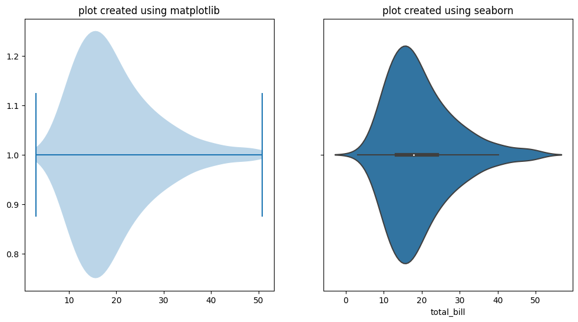

```python
# # !pip install jupyterthemes
# from jupyterthemes import jtplot
# jtplot.style(theme='default', context='notebook', ticks=True, grid=False)

import matplotlib.pyplot as plt
import pandas as pd

# Initialize Figure and Axes object
fig, (ax1, ax2) = plt.subplots(1, 2, figsize=(12, 6))

ax1.set_title('plot created using matplotlib')
ax2.set_title('plot created using seaborn')

# Load in data
tips = pd.read_csv("https://raw.githubusercontent.com/mwaskom/seaborn-data/master/tips.csv")

# Create violinplot which draw a combination of boxplot and kernel density estimate.
ax1.violinplot(tips["total_bill"], vert=False)


import seaborn as sns
# Load the data
tips = sns.load_dataset("tips")

# Create violinplot
sns.violinplot(x = "total_bill", data=tips, ax=ax2)
```

# Convert jupyter notebook to html

```python
# this is how to mount google drive to be usable and reachable as data storage
from google.colab import drive
drive.mount('/content/drive')
```

```python
# convert colab nb to html
%%shell
jupyter-nbconvert --to html /content/drive/MyDrive/Teaching/MLP/2023_autumn/W0-Intro_to_Pyton.ipynb
```